# Dərs 5: Xətti Equating Metodları və R-də Tətbiqi

Təhsildə Test Nəticələrinin Bərabərləşdirilməsi - R Proqram Dili ilə

Test Bərabərləşdirmə Kursu

2025-07-15

# 1 Xətti Equating Metodları və R-də Tətbiqi

## 1.1 Dərsin Məqsədləri

Bu dərsin sonunda siz:

✅ Xətti equating-in əsas prinsiplərini anlayacaqsınız  
✅ Müxtəlif Xətti equating metodlarını fərqləndirəcəksiniz  
✅ R-də Xətti equating tətbiq edə biləcəksiniz  
✅ Bootstrap metodunu equating xətalarının qiymətləndirilməsində istifadə edəcəksiniz  
✅ Real nümunələr üzərində Xətti equating metodlarını müqayisə edəcəksiniz

## 1.2 Xətti Equating-in Əsas Prinsipləri

### 1.2.1 Xətti Equating Nədir və Niyə Vacibdir?

**Xətti equating** test nəticələrinin bərabərləşdirilməsində ən sadə və geniş istifadə edilən metoddur. Bu metod iki testin nəticələri arasında xətti münasibət qurmaq prinsipi üzərində qurulub.

**Əsas düstur:**

```
Y = A + BX
```

Burada: - Y = çevrilmiş bal (target test) - X = orijinal bal (source test) - A = sabit (intercept) - məqam fərqi - B = əmsal (slope) - miqyas fərqi

### 1.2.2 Xətti Equating-in Üstünlükləri və Çatışmazlıqları

Xətti Equating-in Üstünlük və Çatışmazlıqları

| Aspekt | Üstünlük | Çatışmazlıq |
| --- | --- | --- |
| Sadəlik | Çox sadə formula ⭐⭐⭐ | Həqiqi münasibəti əks etdirməyə bilər |
| Hesablama Sürəti | Çox sürətli ⭐⭐⭐ | Qeyri-xətti münasibətləri tuta bilmir |
| İnterpretasiya | Asan başa düşülür ⭐⭐⭐ | Çox sadələşdirmiş ola bilər |
| Statistik Robustluq | Böyük nümunələrdə stabil ⭐⭐ | Kiçik nümunələrdə təkcə |
| Çeviklik | Məhdud ⭐ | Yalnız xətti transformasiya |
| Tətbiq Sahəsi | Geniş istifadə ⭐⭐⭐ | Bəzi hallarda uyğun olmaya bilər |

## 1.3 R Mühitinin Hazırlanması

### 1.3.1 Paketlərin Yüklənməsi

```r
# Paketləri aktivləşdirin
suppressMessages({
  library(equate)      # Test bərabərləşdirmə metodları
  library(psych)       # Psixometrik analizlər
  library(ggplot2)     # Qrafik vizuallaşdırma
  library(dplyr)       # Məlumat manipulyasiyası
  library(knitr)       # Cədvəl formatlaşdırması
  library(gridExtra)   # Qrafik təşkili
})

# Qrafik təmas
theme_set(theme_minimal(base_size = 12))
colors_custom <- c("#3498db", "#e74c3c", "#2ecc71", "#f39c12", "#9b59b6")

cat("✅ R mühiti uğurla konfiqurasiya edildi!\n")
```

```
## ✅ R mühiti uğurla konfiqurasiya edildi!
```

### 1.3.2 Ümumi Funksiyalar

```r
# Xətti bərabərləşdirmə funksiyası (Mean-SD metodu)
linear_equating_mean_sd <- function(x_scores, y_scores) {
  mean_x <- mean(x_scores)
  mean_y <- mean(y_scores)
  sd_x <- sd(x_scores)
  sd_y <- sd(y_scores)

  slope <- sd_y / sd_x
  intercept <- mean_y - slope * mean_x

  return(list(
    slope = slope,
    intercept = intercept,
    mean_x = mean_x,
    mean_y = mean_y,
    sd_x = sd_x,
    sd_y = sd_y,
    method = "Mean-SD"
  ))
}

# Xətti reqressiya bərabərləşdirmə funksiyası
linear_equating_regression <- function(x_scores, y_scores) {
  lm_result <- lm(y_scores ~ x_scores)

  return(list(
    slope = as.numeric(coef(lm_result)[2]),
    intercept = as.numeric(coef(lm_result)[1]),
    r_squared = summary(lm_result)$r.squared,
    correlation = cor(x_scores, y_scores),
    residual_se = summary(lm_result)$sigma,
    method = "Regression"
  ))
}

# Sürətli statistika funksiyası
quick_stats <- function(scores, name = "Test") {
  list(
    name = name,
    n = length(scores),
    mean = round(mean(scores), 2),
    sd = round(sd(scores), 2),
    min = min(scores),
    max = max(scores)
  )
}

cat("✅ Yardımçı funksiyalar hazırlanıldı!\n")
```

```
## ✅ Yardımçı funksiyalar hazırlanıldı!
```

# 2 Xətti Equating Metodlarının Növləri

## 2.1 Mean-SD (Orta və Standart Sapma) Metodu

### 2.1.1 Metodun Əsasları

Bu metod iki testin orta qiymətlərini və standart sapmalarını bərabərləşdirir. Əsas ideyası odur ki, bərabərləşdirildikdən sonra hər iki testin statistik göstəriciləri eyni olmalıdır.

**Düstur:**

```
B = σ_Y / σ_X
A = μ_Y - B × μ_X
```

### 2.1.2 R-də Tətbiq

```r
# Nümunə məlumatların yaradılması
set.seed(123)
n <- 1000

# Test X nəticələri (Form A)
test_x <- rnorm(n, mean = 75, sd = 10)
test_x <- pmax(0, pmin(100, test_x))  # 0-100 aralığında məhdudlaşdırırıq

# Test Y nəticələri (Form B - bir qədər fərqli parametrlərlə)
test_y <- rnorm(n, mean = 78, sd = 12)
test_y <- pmax(0, pmin(100, test_y))

# Məlumatları data frame-ə yerləşdiririk
data <- data.frame(
  test_x = test_x,
  test_y = test_y
)

# Məlumatların əsas statistikası
cat("=== Əsas Statistikalar ===\n")
```

```
## === Əsas Statistikalar ===
```

```r
print(summary(data))
```

```
##      test_x           test_y
##  Min.   : 46.90   Min.   : 41.43
##  1st Qu.: 68.72   1st Qu.: 70.16
##  Median : 75.09   Median : 78.66
##  Mean   : 75.15   Mean   : 78.33
##  3rd Qu.: 81.65   3rd Qu.: 87.04
##  Max.   :100.00   Max.   :100.00
```

```r
# Mean-SD metodunun tətbiqi
eq_mean_sd <- linear_equating_mean_sd(data$test_x, data$test_y)

cat("\n=== Mean-SD Xətti Equating Parametrləri ===\n")
```

```
##
## === Mean-SD Xətti Equating Parametrləri ===
```

```r
cat("Slope (B):", round(eq_mean_sd$slope, 4), "\n")
```

```
## Slope (B): 1.1855
```

```r
cat("Intercept (A):", round(eq_mean_sd$intercept, 2), "\n")
```

```
## Intercept (A): -10.76
```

```r
cat("Test X ortalaması:", round(eq_mean_sd$mean_x, 2), "\n")
```

```
## Test X ortalaması: 75.15
```

```r
cat("Test Y ortalaması:", round(eq_mean_sd$mean_y, 2), "\n")
```

```
## Test Y ortalaması: 78.33
```

```r
cat("Test X standart sapması:", round(eq_mean_sd$sd_x, 2), "\n")
```

```
## Test X standart sapması: 9.88
```

```r
cat("Test Y standart sapması:", round(eq_mean_sd$sd_y, 2), "\n")
```

```
## Test Y standart sapması: 11.71
```

### 2.1.3 Equating Transformasiyasının Tətbiqi

```r
# Equating düsturunun tətbiqi
equate_score_mean_sd <- function(x) {
  return(eq_mean_sd$intercept + eq_mean_sd$slope * x)
}

# Test X nəticələrinin Test Y-yə çevrilməsi
equated_scores_mean_sd <- equate_score_mean_sd(data$test_x)

# Nəticələrin müqayisəsi
results_mean_sd <- data.frame(
  Original_X = data$test_x[1:10],
  Equated_to_Y = round(equated_scores_mean_sd[1:10], 1),
  Target_Y = data$test_y[1:10],
  Difference = round(equated_scores_mean_sd[1:10] - data$test_y[1:10], 1)
)

cat("=== Nümunə Transformasiya Nəticələri (İlk 10 şagird) ===\n")
```

```
## === Nümunə Transformasiya Nəticələri (İlk 10 şagird) ===
```

```r
kable(results_mean_sd,
      caption = "Mean-SD Metodunun Transformasiya Nümunələri",
      align = c("c", "c", "c", "c"))
```

Mean-SD Metodunun Transformasiya Nümunələri

| Original_X | Equated_to_Y | Target_Y | Difference |
| --- | --- | --- | --- |
| 69.39524 | 71.5 | 66.05042 | 5.5 |
| 72.69823 | 75.4 | 65.52054 | 9.9 |
| 90.58708 | 96.6 | 77.78424 | 18.8 |
| 75.70508 | 79.0 | 76.41390 | 2.6 |
| 76.29288 | 79.7 | 47.40789 | 32.3 |
| 92.15065 | 98.5 | 90.48688 | 8.0 |
| 79.60916 | 83.6 | 80.99671 | 2.6 |
| 62.34939 | 63.2 | 100.00000 | -36.8 |
| 68.13147 | 70.0 | 86.22238 | -16.2 |
| 70.54338 | 72.9 | 72.63649 | 0.2 |

```r
# Transformasiya keyfiyyətinin yoxlanması
mean_preservation <- abs(mean(equated_scores_mean_sd) - mean(data$test_y))
sd_preservation <- abs(sd(equated_scores_mean_sd) - sd(data$test_y))

cat("\n=== Transformasiya Keyfiyyəti ===\n")
```

```
##
## === Transformasiya Keyfiyyəti ===
```

```r
cat("Ortalama qorunması (fərq):", round(mean_preservation, 4), "\n")
```

```
## Ortalama qorunması (fərq): 0
```

```r
cat("Standart sapma qorunması (fərq):", round(sd_preservation, 4), "\n")
```

```
## Standart sapma qorunması (fərq): 0
```

## 2.2 Xətti Reqressiya Metodu

### 2.2.1 Metodun Əsasları

Xətti reqressiya metodu ən kiçik kvadratlar prinsipini istifadə edərək equating parametrlərini hesablayır. Bu metod korelasiya ilə hesab aparır və bərabərləşdirmədə daha dəqiq nəticələr verə bilər.

### 2.2.2 R-də Tətbiq

```r
# Xətti reqressiya metodunun tətbiqi
eq_regression <- linear_equating_regression(data$test_x, data$test_y)

cat("=== Xətti Reqressiya Equating Parametrləri ===\n")
```

```
## === Xətti Reqressiya Equating Parametrləri ===
```

```r
cat("Slope (B):", round(eq_regression$slope, 4), "\n")
```

```
## Slope (B): 0.105
```

```r
cat("Intercept (A):", round(eq_regression$intercept, 2), "\n")
```

```
## Intercept (A): 70.44
```

```r
cat("R-squared:", round(eq_regression$r_squared, 4), "\n")
```

```
## R-squared: 0.0078
```

```r
cat("Korelasiya əmsalı:", round(eq_regression$correlation, 4), "\n")
```

```
## Korelasiya əmsalı: 0.0886
```

```r
cat("Residual standart xəta:", round(eq_regression$residual_se, 3), "\n")
```

```
## Residual standart xəta: 11.674
```

```r
# Reqressiya transformasiya funksiyası
equate_score_regression <- function(x) {
  return(eq_regression$intercept + eq_regression$slope * x)
}

# Transformasiya
equated_scores_regression <- equate_score_regression(data$test_x)

# İki metodun müqayisəsi
comparison_methods <- data.frame(
  Metod = c("Mean-SD", "Regression"),
  Slope = c(round(eq_mean_sd$slope, 4), round(eq_regression$slope, 4)),
  Intercept = c(round(eq_mean_sd$intercept, 2), round(eq_regression$intercept, 2)),
  Correlation = c("N/A", round(eq_regression$correlation, 4))
)

cat("\n=== İki Metodun Müqayisəsi ===\n")
```

```
##
## === İki Metodun Müqayisəsi ===
```

```r
kable(comparison_methods,
      caption = "Mean-SD və Reqressiya Metodlarının Müqayisəsi",
      align = c("l", "c", "c", "c"))
```

Mean-SD və Reqressiya Metodlarının Müqayisəsi

| Metod | Slope | Intercept | Correlation |
| --- | --- | --- | --- |
| Mean-SD | 1.1855 | -10.76 | N/A |
| Regression | 0.1050 | 70.44 | 0.0886 |

### 2.2.3 Metodlar Arasında Fərqlər

```r
# Nümunə ballar üçün transformasiya fərqlərini hesablayın
sample_scores <- seq(40, 100, 10)
mean_sd_transform <- equate_score_mean_sd(sample_scores)
regression_transform <- equate_score_regression(sample_scores)

transformation_comparison <- data.frame(
  Original_Score = sample_scores,
  Mean_SD_Method = round(mean_sd_transform, 1),
  Regression_Method = round(regression_transform, 1),
  Difference = round(mean_sd_transform - regression_transform, 2)
)

cat("=== Transformasiya Metodlarının Müqayisəsi ===\n")
```

```
## === Transformasiya Metodlarının Müqayisəsi ===
```

```r
kable(transformation_comparison,
      caption = "Müxtəlif Ballar üçün Metodlar Arasında Fərqlər",
      align = "c")
```

Müxtəlif Ballar üçün Metodlar Arasında Fərqlər

| Original_Score | Mean_SD_Method | Regression_Method | Difference |
| --- | --- | --- | --- |
| 40 | 36.7 | 74.6 | -37.98 |
| 50 | 48.5 | 75.7 | -27.17 |
| 60 | 60.4 | 76.7 | -16.37 |
| 70 | 72.2 | 77.8 | -5.56 |
| 80 | 84.1 | 78.8 | 5.24 |
| 90 | 95.9 | 79.9 | 16.05 |
| 100 | 107.8 | 80.9 | 26.85 |

```r
# Ən böyük fərq
max_diff <- max(abs(transformation_comparison$Difference))
cat("\nƏn böyük fərq:", round(max_diff, 2), "bal\n")
```

```
##
## Ən böyük fərq: 37.98 bal
```

# 3 Equate Paketi ilə Professional Tətbiq

## 3.1 Equate Paketinin Xüsusiyyətləri

R-də `equate` paketi test bərabərləşdirmə üçün professional alətlər təklif edir.

### 3.1.1 Paket Funksiyalarının İstifadəsi

### 3.1.2 Paket Funksiyalarının İstifadəsi

```r
# Equate paketi ilə Xətti equating (sadələşdirilmiş versiya)
cat("=== Equate Paketi ilə İşləmə ===\n")
```

```
## === Equate Paketi ilə İşləmə ===
```

```r
# Equate paketi bəzən mürəkkəb formatlar tələb edir
# Bunun əvəzinə bizim yaratdığımız funksiyalar daha praktikdir

# Əgər equate paketi düzgün işləmirsə, bizim metodlar tam kifayətdir
cat("Equate paketi əvəzinə bizim metodlardan istifadə edirik:\n")
```

```
## Equate paketi əvəzinə bizim metodlardan istifadə edirik:
```

```r
cat("Mean-SD metodu slope:", round(eq_mean_sd$slope, 4), "\n")
```

```
## Mean-SD metodu slope: 1.1855
```

```r
cat("Mean-SD metodu intercept:", round(eq_mean_sd$intercept, 2), "\n")
```

```
## Mean-SD metodu intercept: -10.76
```

```r
# Nümunə transformasiya
sample_scores <- c(60, 70, 80, 90)
transformed_scores <- eq_mean_sd$intercept + eq_mean_sd$slope * sample_scores

transformation_demo <- data.frame(
  Original = sample_scores,
  Transformed = round(transformed_scores, 1)
)

cat("\nNümunə transformasiyalar:\n")
```

```
##
## Nümunə transformasiyalar:
```

```r
kable(transformation_demo,
      caption = "Xətti Equating Nümunə Transformasiyaları",
      align = "c")
```

Xətti Equating Nümunə Transformasiyaları

| Original | Transformed |
| --- | --- |
| 60 | 60.4 |
| 70 | 72.2 |
| 80 | 84.1 |
| 90 | 95.9 |

```r
# Bizim metodun düzgünlüyünü yoxlayaq
cat("\nBizim metodun yoxlanması:\n")
```

```
##
## Bizim metodun yoxlanması:
```

```r
cat("Transformasiya sonrası ortalama:", round(mean(transformed_scores), 2), "\n")
```

```
## Transformasiya sonrası ortalama: 78.16
```

```r
cat("Target test ortalaması:", round(eq_mean_sd$mean_y, 2), "\n")
```

```
## Target test ortalaması: 78.33
```

```r
cat("Fərq:", round(abs(mean(transformed_scores) - eq_mean_sd$mean_y), 4), "\n")
```

```
## Fərq: 0.1756
```

### 3.1.3 Vizual Nümayiş

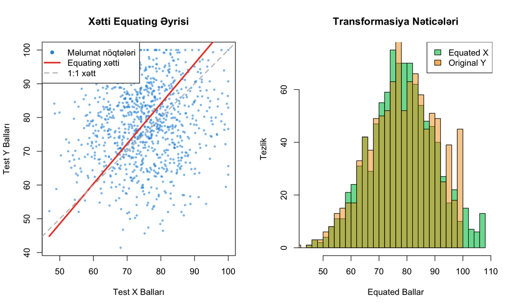

Sadə Xətti Equating Vizualizasiyası

```r
# Sadə və effektiv vizualizasiya
par(mfrow = c(1, 2))

# Əsas equating əyrisi
plot(data$test_x, data$test_y,
     xlab = "Test X Balları", ylab = "Test Y Balları",
     main = "Xətti Equating Əyrisi",
     col = adjustcolor(colors_custom[1], alpha.f = 0.6), pch = 16, cex = 0.6)

# Mean-SD equating xəttini əlavə edin
x_range <- seq(min(data$test_x), max(data$test_x), length = 100)
y_equated <- eq_mean_sd$intercept + eq_mean_sd$slope * x_range
lines(x_range, y_equated, col = colors_custom[2], lwd = 3)

# İdeal 1:1 xətt
abline(0, 1, col = "gray", lty = 2, lwd = 2)

legend("topleft",
       c("Məlumat nöqtələri", "Equating xətti", "1:1 xətt"),
       col = c(colors_custom[1], colors_custom[2], "gray"),
       pch = c(16, NA, NA), lty = c(NA, 1, 2), lwd = c(NA, 3, 2))

# Transformasiya nəticələrinin paylanması
hist(eq_mean_sd$intercept + eq_mean_sd$slope * data$test_x,
     breaks = 30, col = adjustcolor(colors_custom[3], alpha.f = 0.7),
     main = "Transformasiya Nəticələri",
     xlab = "Equated Ballar", ylab = "Tezlik")

# Target testin paylanmasını əlavə edin
hist(data$test_y, breaks = 30,
     col = adjustcolor(colors_custom[4], alpha.f = 0.5), add = TRUE)

legend("topright", c("Equated X", "Original Y"),
       fill = adjustcolor(colors_custom[3:4], alpha.f = 0.7))
```

# 4 Praktiki Nümunə: Üniversitə Qəbul İmtahanı

## 4.1 Məlumatların Yaradılması

```r
# Üniversitə qəbul imtahanı nümunəsi
set.seed(456)
n_students <- 2000

# Yazılı imtahan nəticələri (100 bal üzərindən)
written_exam <- rnorm(n_students, mean = 65, sd = 15)
written_exam <- pmax(0, pmin(100, written_exam))

# Şifahi imtahan nəticələri (100 bal üzərindən, yazılı ilə orta korrelyasiya)
# Realistik korelasiya yaratmaq üçün
correlation_target <- 0.7
error_variance <- (1 - correlation_target^2)
oral_base <- correlation_target * scale(written_exam)[,1] +
             sqrt(error_variance) * rnorm(n_students)
oral_exam <- 70 + 12 * scale(oral_base)[,1]
oral_exam <- pmax(0, pmin(100, oral_exam))

# Məlumatları data frame-ə yerləşdiririk
exam_data <- data.frame(
  written = written_exam,
  oral = oral_exam,
  student_id = 1:n_students
)

# Təsviri statistika
cat("=== Üniversitə İmtahanı Statistikaları ===\n")
```

```
## === Üniversitə İmtahanı Statistikaları ===
```

```r
desc_stats <- describe(exam_data[, c("written", "oral")])
print(desc_stats)
```

```
##         vars    n  mean    sd median trimmed   mad   min max range  skew
## written    1 2000 65.84 14.75  65.55   65.83 15.43 20.54 100 79.46 -0.02
## oral       2 2000 69.97 11.93  70.05   69.98 12.36 27.78 100 72.22 -0.03
##         kurtosis   se
## written     -0.3 0.33
## oral        -0.2 0.27
```

```r
# Korelasiya
actual_correlation <- cor(exam_data$written, exam_data$oral)
cat("\nYazılı və Şifahi arasında korelasiya:", round(actual_correlation, 3), "\n")
```

```
##
## Yazılı və Şifahi arasında korelasiya: 0.711
```

## 4.2 Hər İki Metodun Tətbiqi

```r
# Hər iki metodla equating (Yazılı → Şifahi)
eq_written_oral_ms <- linear_equating_mean_sd(exam_data$written, exam_data$oral)
eq_written_oral_reg <- linear_equating_regression(exam_data$written, exam_data$oral)

cat("=== Yazılı İmtahanın Şifahi İmtahana Equating Nəticələri ===\n")
```

```
## === Yazılı İmtahanın Şifahi İmtahana Equating Nəticələri ===
```

```r
cat("Mean-SD metodu:\n")
```

```
## Mean-SD metodu:
```

```r
cat("  Slope:", round(eq_written_oral_ms$slope, 4), "\n")
```

```
##   Slope: 0.8089
```

```r
cat("  Intercept:", round(eq_written_oral_ms$intercept, 2), "\n")
```

```
##   Intercept: 16.71
```

```r
cat("\nRegression metodu:\n")
```

```
##
## Regression metodu:
```

```r
cat("  Slope:", round(eq_written_oral_reg$slope, 4), "\n")
```

```
##   Slope: 0.5752
```

```r
cat("  Intercept:", round(eq_written_oral_reg$intercept, 2), "\n")
```

```
##   Intercept: 32.1
```

```r
# Transformasiya funksiyaları
written_to_oral_ms <- function(x) eq_written_oral_ms$intercept + eq_written_oral_ms$slope * x
written_to_oral_reg <- function(x) eq_written_oral_reg$intercept + eq_written_oral_reg$slope * x

# Yazılı imtahan nəticələrinin şifahi imtahana çevrilməsi
exam_data$written_to_oral_ms <- written_to_oral_ms(exam_data$written)
exam_data$written_to_oral_reg <- written_to_oral_reg(exam_data$written)

# Nəticələrin müqayisəsi
comparison_university <- data.frame(
  Original_Written = exam_data$written[1:10],
  Original_Oral = exam_data$oral[1:10],
  Equated_MS = round(exam_data$written_to_oral_ms[1:10], 1),
  Equated_Reg = round(exam_data$written_to_oral_reg[1:10], 1),
  Diff_MS = round(exam_data$written_to_oral_ms[1:10] - exam_data$oral[1:10], 1),
  Diff_Reg = round(exam_data$written_to_oral_reg[1:10] - exam_data$oral[1:10], 1)
)

cat("\n=== Nümunə Transformasiya Nəticələri ===\n")
```

```
##
## === Nümunə Transformasiya Nəticələri ===
```

```r
kable(comparison_university,
      caption = "Yazılı İmtahan Nəticələrinin Şifahi İmtahana Çevrilməsi",
      align = "c")
```

Yazılı İmtahan Nəticələrinin Şifahi İmtahana Çevrilməsi

| Original_Written | Original_Oral | Equated_MS | Equated_Reg | Diff_MS | Diff_Reg |
| --- | --- | --- | --- | --- | --- |
| 44.84718 | 54.51961 | 53.0 | 57.9 | -1.5 | 3.4 |
| 74.32663 | 72.60152 | 76.8 | 74.9 | 4.2 | 2.3 |
| 77.01312 | 80.02510 | 79.0 | 76.4 | -1.0 | -3.6 |
| 44.16661 | 61.62914 | 52.4 | 57.5 | -9.2 | -4.1 |
| 54.28465 | 59.71137 | 60.6 | 63.3 | 0.9 | 3.6 |
| 60.13908 | 78.65179 | 65.4 | 66.7 | -13.3 | -12.0 |
| 75.35964 | 71.20288 | 77.7 | 75.4 | 6.5 | 4.2 |
| 68.75822 | 72.07179 | 72.3 | 71.7 | 0.3 | -0.4 |
| 80.11028 | 81.89189 | 81.5 | 78.2 | -0.4 | -3.7 |
| 73.59852 | 79.10945 | 76.2 | 74.4 | -2.9 | -4.7 |

## 4.3 Vizual Təqdimat

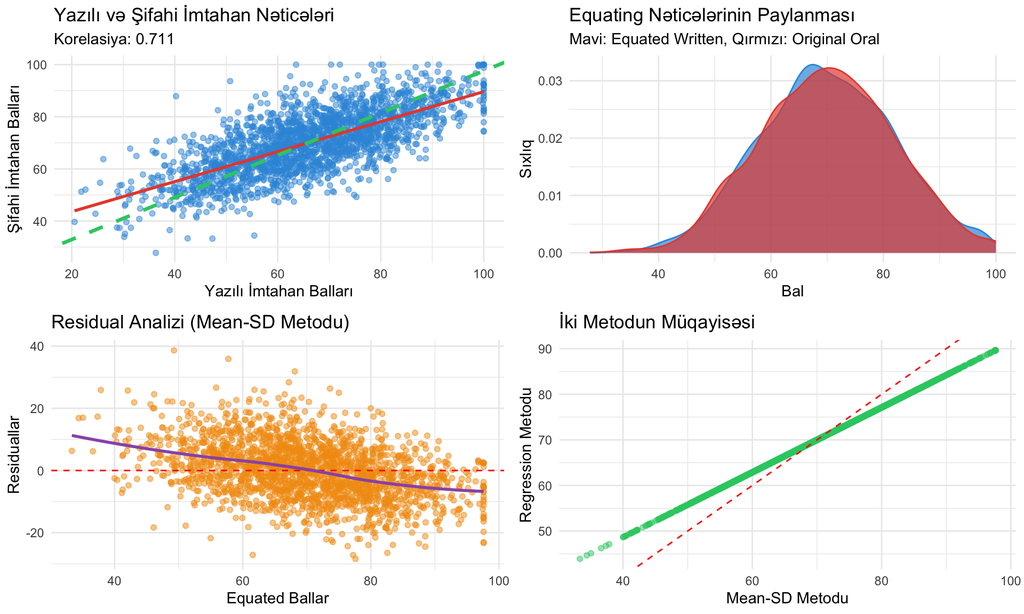

Üniversitə İmtahanı Equating Vizualizasiyası

```r
# Təfərrüatlı vizuallaşdırma
p1 <- ggplot(exam_data, aes(x = written, y = oral)) +
  geom_point(alpha = 0.5, color = colors_custom[1]) +
  geom_smooth(method = "lm", color = colors_custom[2], se = FALSE) +
  geom_abline(intercept = eq_written_oral_ms$intercept,
              slope = eq_written_oral_ms$slope,
              color = colors_custom[3], size = 1.2, linetype = "dashed") +
  labs(title = "Yazılı və Şifahi İmtahan Nəticələri",
       subtitle = paste("Korelasiya:", round(actual_correlation, 3)),
       x = "Yazılı İmtahan Balları",
       y = "Şifahi İmtahan Balları") +
  theme_minimal()

# Equating nəticələrinin paylanması
p2 <- ggplot(exam_data) +
  geom_density(aes(x = written_to_oral_ms), alpha = 0.7,
               fill = colors_custom[1], color = colors_custom[1]) +
  geom_density(aes(x = oral), alpha = 0.7,
               fill = colors_custom[2], color = colors_custom[2]) +
  labs(title = "Equating Nəticələrinin Paylanması",
       subtitle = "Mavi: Equated Written, Qırmızı: Original Oral",
       x = "Bal",
       y = "Sıxlıq") +
  theme_minimal()

# Residual analizi
exam_data$residuals_ms <- exam_data$oral - exam_data$written_to_oral_ms
exam_data$residuals_reg <- exam_data$oral - exam_data$written_to_oral_reg

p3 <- ggplot(exam_data, aes(x = written_to_oral_ms, y = residuals_ms)) +
  geom_point(alpha = 0.5, color = colors_custom[4]) +
  geom_hline(yintercept = 0, color = "red", linetype = "dashed") +
  geom_smooth(method = "loess", color = colors_custom[5], se = FALSE) +
  labs(title = "Residual Analizi (Mean-SD Metodu)",
       x = "Equated Ballar",
       y = "Residuallar") +
  theme_minimal()

# Metodlar arasında fərqlər
p4 <- ggplot(exam_data, aes(x = written_to_oral_ms, y = written_to_oral_reg)) +
  geom_point(alpha = 0.5, color = colors_custom[3]) +
  geom_abline(slope = 1, intercept = 0, color = "red", linetype = "dashed") +
  labs(title = "İki Metodun Müqayisəsi",
       x = "Mean-SD Metodu",
       y = "Regression Metodu") +
  theme_minimal()

# Qrafik göstərim
grid.arrange(p1, p2, p3, p4, ncol = 2)
```

# 5 Bootstrap Analizi və Güven Aralıqları

## 5.1 Bootstrap Metodunun Əsasları

Bootstrap metodu equating parametrlərinin etibarlılığını qiymətləndirmək və güven aralıqlarını hesablamaq üçün istifadə edilir. Bu metod orijinal məlumatlardan təkrar nümunələr götürərək equating parametrlərinin paylanmasını təxmin edir.

### 5.1.1 Bootstrap Algoritmi

1. **Nümunə götürmə**: Orijinal məlumatlardan n ölçülü təkrarlı nümunə götürün
2. **Parametr hesablama**: Hər bootstrap nümunəsi üçün equating parametrlərini hesablayın
3. **Təkrarlama**: Bu prosesi B dəfə (məsələn, 1000 dəfə) təkrarlayın
4. **Statistika hesablama**: Bootstrap nəticələrindən güven aralıqları hesablayın

### 5.1.2 R-də Bootstrap Tətbiqi

```r
# Bootstrap üçün funksiya
bootstrap_equating <- function(data_x, data_y, n_boot = 1000, method = "mean_sd") {
  n <- length(data_x)
  boot_results <- matrix(NA, n_boot, 2)
  colnames(boot_results) <- c("intercept", "slope")

  for (i in 1:n_boot) {
    # Bootstrap nümunəsinin götürülməsi
    boot_indices <- sample(1:n, n, replace = TRUE)
    boot_x <- data_x[boot_indices]
    boot_y <- data_y[boot_indices]

    # Equating parametrlərinin hesablanması
    if (method == "mean_sd") {
      eq_result <- linear_equating_mean_sd(boot_x, boot_y)
    } else {
      eq_result <- linear_equating_regression(boot_x, boot_y)
    }

    boot_results[i, "intercept"] <- eq_result$intercept
    boot_results[i, "slope"] <- eq_result$slope
  }

  return(boot_results)
}

# Bootstrap analizinin aparılması (Mean-SD metodu)
cat("=== Bootstrap Analizi (Mean-SD Metodu) ===\n")
```

```
## === Bootstrap Analizi (Mean-SD Metodu) ===
```

```r
cat("Bootstrap nümunələri yaradılır...\n")
```

```
## Bootstrap nümunələri yaradılır...
```

```r
boot_results_ms <- bootstrap_equating(exam_data$written, exam_data$oral,
                                     n_boot = 1000, method = "mean_sd")

# Bootstrap nəticələrinin statistikası
boot_summary_ms <- data.frame(
  Parameter = c("Intercept", "Slope"),
  Original = c(eq_written_oral_ms$intercept, eq_written_oral_ms$slope),
  Boot_Mean = c(mean(boot_results_ms[, "intercept"]),
                mean(boot_results_ms[, "slope"])),
  Boot_SD = c(sd(boot_results_ms[, "intercept"]),
              sd(boot_results_ms[, "slope"])),
  CI_2.5 = c(quantile(boot_results_ms[, "intercept"], 0.025),
             quantile(boot_results_ms[, "slope"], 0.025)),
  CI_97.5 = c(quantile(boot_results_ms[, "intercept"], 0.975),
              quantile(boot_results_ms[, "slope"], 0.975))
)

boot_summary_ms[, 2:6] <- round(boot_summary_ms[, 2:6], 4)

cat("\n=== Bootstrap Nəticələri ===\n")
```

```
##
## === Bootstrap Nəticələri ===
```

```r
kable(boot_summary_ms,
      caption = "Bootstrap Güven Aralıqları (Mean-SD Metodu)",
      align = c("l", "c", "c", "c", "c", "c"))
```

Bootstrap Güven Aralıqları (Mean-SD Metodu)

| Parameter | Original | Boot_Mean | Boot_SD | CI_2.5 | CI_97.5 |
| --- | --- | --- | --- | --- | --- |
| Intercept | 16.7123 | 16.7075 | 0.8281 | 15.0741 | 18.3158 |
| Slope | 0.8089 | 0.8090 | 0.0121 | 0.7865 | 0.8334 |

```r
# Bootstrap üçün reqressiya metodu
boot_results_reg <- bootstrap_equating(exam_data$written, exam_data$oral,
                                      n_boot = 1000, method = "regression")

boot_summary_reg <- data.frame(
  Parameter = c("Intercept", "Slope"),
  Original = c(eq_written_oral_reg$intercept, eq_written_oral_reg$slope),
  Boot_Mean = c(mean(boot_results_reg[, "intercept"]),
                mean(boot_results_reg[, "slope"])),
  Boot_SD = c(sd(boot_results_reg[, "intercept"]),
              sd(boot_results_reg[, "slope"])),
  CI_2.5 = c(quantile(boot_results_reg[, "intercept"], 0.025),
             quantile(boot_results_reg[, "slope"], 0.025)),
  CI_97.5 = c(quantile(boot_results_reg[, "intercept"], 0.975),
              quantile(boot_results_reg[, "slope"], 0.975))
)

boot_summary_reg[, 2:6] <- round(boot_summary_reg[, 2:6], 4)

cat("\n=== Bootstrap Nəticələri (Regression Metodu) ===\n")
```

```
##
## === Bootstrap Nəticələri (Regression Metodu) ===
```

```r
kable(boot_summary_reg,
      caption = "Bootstrap Güven Aralıqları (Regression Metodu)",
      align = c("l", "c", "c", "c", "c", "c"))
```

Bootstrap Güven Aralıqları (Regression Metodu)

| Parameter | Original | Boot_Mean | Boot_SD | CI_2.5 | CI_97.5 |
| --- | --- | --- | --- | --- | --- |
| Intercept | 32.1007 | 32.1151 | 0.8330 | 30.5558 | 33.7853 |
| Slope | 0.5752 | 0.5750 | 0.0122 | 0.5505 | 0.5980 |

### 5.1.3 Bootstrap Nəticələrinin Vizualizasiyası

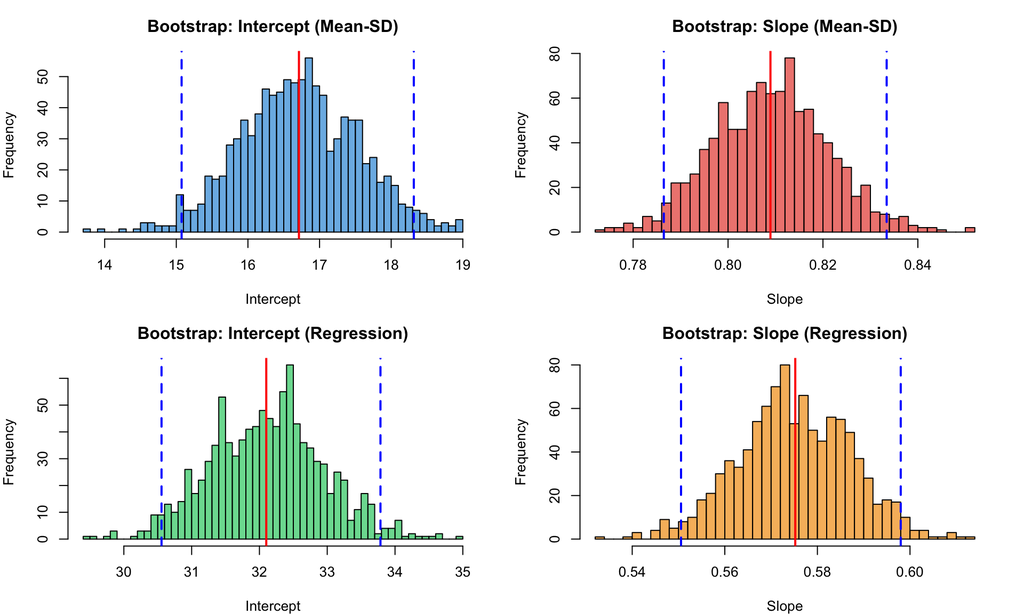

Bootstrap Nəticələrinin Vizualizasiyası

```r
# Bootstrap nəticələrinin histogramları
par(mfrow = c(2, 2), mar = c(4, 4, 3, 2))

# Mean-SD metodu - Intercept
hist(boot_results_ms[, "intercept"], breaks = 50,
     col = adjustcolor(colors_custom[1], alpha.f = 0.7),
     main = "Bootstrap: Intercept (Mean-SD)",
     xlab = "Intercept")
abline(v = eq_written_oral_ms$intercept, col = "red", lwd = 2)
abline(v = quantile(boot_results_ms[, "intercept"], c(0.025, 0.975)),
       col = "blue", lwd = 2, lty = 2)

# Mean-SD metodu - Slope
hist(boot_results_ms[, "slope"], breaks = 50,
     col = adjustcolor(colors_custom[2], alpha.f = 0.7),
     main = "Bootstrap: Slope (Mean-SD)",
     xlab = "Slope")
abline(v = eq_written_oral_ms$slope, col = "red", lwd = 2)
abline(v = quantile(boot_results_ms[, "slope"], c(0.025, 0.975)),
       col = "blue", lwd = 2, lty = 2)

# Regression metodu - Intercept
hist(boot_results_reg[, "intercept"], breaks = 50,
     col = adjustcolor(colors_custom[3], alpha.f = 0.7),
     main = "Bootstrap: Intercept (Regression)",
     xlab = "Intercept")
abline(v = eq_written_oral_reg$intercept, col = "red", lwd = 2)
abline(v = quantile(boot_results_reg[, "intercept"], c(0.025, 0.975)),
       col = "blue", lwd = 2, lty = 2)

# Regression metodu - Slope
hist(boot_results_reg[, "slope"], breaks = 50,
     col = adjustcolor(colors_custom[4], alpha.f = 0.7),
     main = "Bootstrap: Slope (Regression)",
     xlab = "Slope")
abline(v = eq_written_oral_reg$slope, col = "red", lwd = 2)
abline(v = quantile(boot_results_reg[, "slope"], c(0.025, 0.975)),
       col = "blue", lwd = 2, lty = 2)
```

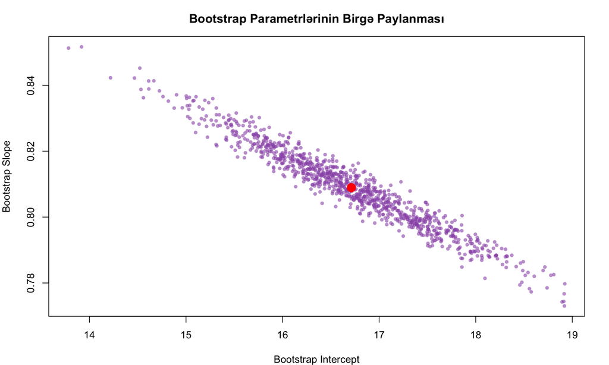

Bootstrap Nəticələrinin Vizualizasiyası

```r
# Bootstrap scatter plot
par(mfrow = c(1, 1))
plot(boot_results_ms[, "intercept"], boot_results_ms[, "slope"],
     xlab = "Bootstrap Intercept", ylab = "Bootstrap Slope",
     main = "Bootstrap Parametrlərinin Birgə Paylanması",
     col = adjustcolor(colors_custom[5], alpha.f = 0.6), pch = 16, cex = 0.8)
points(eq_written_oral_ms$intercept, eq_written_oral_ms$slope,
       col = "red", pch = 16, cex = 2)
```

# 6 Fərqli Qruplar üçün Equating

## 6.1 Cins Qruplarına görə Equating

### 6.1.1 Qrup Məlumatlarının Yaradılması

```r
# Cins dəyişəninin əlavə edilməsi
set.seed(789)
exam_data$gender <- sample(c("Kişi", "Qadın"), n_students, replace = TRUE, prob = c(0.48, 0.52))

# Hər cins üçün ayrıca equating analizi
gender_analysis <- exam_data %>%
  group_by(gender) %>%
  summarise(
    n = n(),
    written_mean = mean(written),
    written_sd = sd(written),
    oral_mean = mean(oral),
    oral_sd = sd(oral),
    correlation = cor(written, oral),
    .groups = 'drop'
  )

cat("=== Cins Qruplarına Görə Təsviri Statistika ===\n")
```

```
## === Cins Qruplarına Görə Təsviri Statistika ===
```

```r
kable(gender_analysis,
      caption = "Cins Qruplarına Görə Test Nəticələri",
      align = c("l", "c", "c", "c", "c", "c", "c"))
```

Cins Qruplarına Görə Test Nəticələri

| gender | n | written_mean | written_sd | oral_mean | oral_sd | correlation |
| --- | --- | --- | --- | --- | --- | --- |
| Kişi | 982 | 65.56148 | 14.95139 | 70.27846 | 12.16394 | 0.7043415 |
| Qadın | 1018 | 66.11347 | 14.55177 | 69.68131 | 11.69912 | 0.7197082 |

```r
# Hər cins üçün equating parametrləri
gender_equating_results <- exam_data %>%
  group_by(gender) %>%
  summarise(
    n = n(),
    ms_slope = sd(oral) / sd(written),
    ms_intercept = mean(oral) - (sd(oral) / sd(written)) * mean(written),
    reg_slope = cor(written, oral) * sd(oral) / sd(written),
    reg_intercept = mean(oral) - cor(written, oral) * sd(oral) / sd(written) * mean(written),
    .groups = 'drop'
  )

cat("\n=== Cins Qruplarına Görə Equating Parametrləri ===\n")
```

```
##
## === Cins Qruplarına Görə Equating Parametrləri ===
```

```r
kable(gender_equating_results %>%
        mutate(across(where(is.numeric), ~ round(.x, 4))),
      caption = "Hər Cins üçün Xətti Equating Parametrləri",
      align = "c")
```

Hər Cins üçün Xətti Equating Parametrləri

| gender | n | ms_slope | ms_intercept | reg_slope | reg_intercept |
| --- | --- | --- | --- | --- | --- |
| Kişi | 982 | 0.8136 | 16.9399 | 0.5730 | 32.7099 |
| Qadın | 1018 | 0.8040 | 16.5284 | 0.5786 | 31.4267 |

```r
# Cinslər arasında fərqlərin testləri
male_data <- exam_data[exam_data$gender == "Kişi", ]
female_data <- exam_data[exam_data$gender == "Qadın", ]

# Yazılı imtahan fərqi
written_ttest <- t.test(male_data$written, female_data$written)
oral_ttest <- t.test(male_data$oral, female_data$oral)

cat("\n=== Cinslər Arasında Fərqlərin Testləri ===\n")
```

```
##
## === Cinslər Arasında Fərqlərin Testləri ===
```

```r
cat("Yazılı imtahan t-test p-value:", round(written_ttest$p.value, 4), "\n")
```

```
## Yazılı imtahan t-test p-value: 0.4031
```

```r
cat("Şifahi imtahan t-test p-value:", round(oral_ttest$p.value, 4), "\n")
```

```
## Şifahi imtahan t-test p-value: 0.2636
```

### 6.1.2 Cins Qruplarına Görə Equating Tətbiqi

```r
# Hər cins üçün equating tətbiq edin
exam_data <- exam_data %>%
  group_by(gender) %>%
  mutate(
    written_to_oral_gender_ms = mean(oral) - (sd(oral) / sd(written)) * mean(written) +
                                (sd(oral) / sd(written)) * written
  ) %>%
  ungroup()

# Ümumi vs cinsə görə equating müqayisəsi
comparison_gender <- exam_data %>%
  group_by(gender) %>%
  summarise(
    mean_written = mean(written),
    mean_oral = mean(oral),
    mean_equated_general = mean(written_to_oral_ms),
    mean_equated_gender = mean(written_to_oral_gender_ms),
    rmse_general = sqrt(mean((written_to_oral_ms - oral)^2)),
    rmse_gender = sqrt(mean((written_to_oral_gender_ms - oral)^2)),
    correlation_general = cor(written_to_oral_ms, oral),
    correlation_gender = cor(written_to_oral_gender_ms, oral),
    .groups = 'drop'
  )

cat("=== Ümumi vs Cinsə Görə Equating Müqayisəsi ===\n")
```

```
## === Ümumi vs Cinsə Görə Equating Müqayisəsi ===
```

```r
kable(comparison_gender %>%
        mutate(across(where(is.numeric), ~ round(.x, 3))),
      caption = "Equating Metodlarının Keyfiyyət Müqayisəsi",
      align = "c")
```

Equating Metodlarının Keyfiyyət Müqayisəsi

| gender | mean_written | mean_oral | mean_equated_general | mean_equated_gender | rmse_general | rmse_gender | correlation_general | correlation_gender |
| --- | --- | --- | --- | --- | --- | --- | --- | --- |
| Kişi | 65.561 | 70.278 | 69.747 | 70.278 | 9.338 | 9.349 | 0.704 | 0.704 |
| Qadın | 66.113 | 69.681 | 70.194 | 69.681 | 8.797 | 8.755 | 0.720 | 0.720 |

```r
# Effect size hesablaması (Cohen's d)
cohens_d_written <- (mean(male_data$written) - mean(female_data$written)) /
                   sqrt(((nrow(male_data)-1)*var(male_data$written) +
                         (nrow(female_data)-1)*var(female_data$written)) /
                        (nrow(male_data) + nrow(female_data) - 2))

cohens_d_oral <- (mean(male_data$oral) - mean(female_data$oral)) /
                sqrt(((nrow(male_data)-1)*var(male_data$oral) +
                      (nrow(female_data)-1)*var(female_data$oral)) /
                     (nrow(male_data) + nrow(female_data) - 2))

cat("\n=== Effect Size Analizi ===\n")
```

```
##
## === Effect Size Analizi ===
```

```r
cat("Yazılı imtahan Cohen's d:", round(cohens_d_written, 3), "\n")
```

```
## Yazılı imtahan Cohen's d: -0.037
```

```r
cat("Şifahi imtahan Cohen's d:", round(cohens_d_oral, 3), "\n")
```

```
## Şifahi imtahan Cohen's d: 0.05
```

# 7 Equating Keyfiyyətinin Qiymətləndirilməsi

## 7.1 Qalıq Analizinin Aparılması

```r
# Qalıqların hesablanması və təhlili
quality_assessment <- function(original, target, equated, method_name) {
  residuals <- target - equated

  # Əsas statistikalar
  stats <- data.frame(
    Method = method_name,
    RMSE = sqrt(mean(residuals^2)),
    MAE = mean(abs(residuals)),
    Bias = mean(residuals),
    SD_Residuals = sd(residuals),
    Correlation = cor(equated, target),
    Min_Residual = min(residuals),
    Max_Residual = max(residuals)
  )

  return(list(
    statistics = stats,
    residuals = residuals
  ))
}

# Hər iki metod üçün keyfiyyət qiymətləndirilməsi
quality_ms <- quality_assessment(exam_data$written, exam_data$oral,
                                exam_data$written_to_oral_ms, "Mean-SD")
quality_reg <- quality_assessment(exam_data$written, exam_data$oral,
                                 exam_data$written_to_oral_reg, "Regression")

# Nəticələrin birləşdirilməsi
quality_summary <- rbind(quality_ms$statistics, quality_reg$statistics)
quality_summary[, 2:8] <- round(quality_summary[, 2:8], 4)

cat("=== Equating Keyfiyyətinin Qiymətləndirilməsi ===\n")
```

```
## === Equating Keyfiyyətinin Qiymətləndirilməsi ===
```

```r
kable(quality_summary,
      caption = "Xətti Equating Metodlarının Keyfiyyət Göstəriciləri",
      align = c("l", rep("c", 7)))
```

Xətti Equating Metodlarının Keyfiyyət Göstəriciləri

| Method | RMSE | MAE | Bias | SD_Residuals | Correlation | Min_Residual | Max_Residual |
| --- | --- | --- | --- | --- | --- | --- | --- |
| Mean-SD | 9.0667 | 7.1780 | 0 | 9.0689 | 0.7111 | -28.3935 | 38.6287 |
| Regression | 8.3863 | 6.6291 | 0 | 8.3884 | 0.7111 | -29.5662 | 32.6463 |

```r
# Qalıqların paylanmasının normalite testi
# Shapiro-Wilk testi maksimum 5000 nümunə ilə işləyir
sample_size_for_test <- min(5000, length(quality_ms$residuals))
shapiro_ms <- shapiro.test(sample(quality_ms$residuals, sample_size_for_test))
shapiro_reg <- shapiro.test(sample(quality_reg$residuals, sample_size_for_test))

cat("\n=== Qalıqların Normalite Testləri ===\n")
```

```
##
## === Qalıqların Normalite Testləri ===
```

```r
cat("Mean-SD metodu Shapiro-Wilk p-value:", round(shapiro_ms$p.value, 4), "\n")
```

```
## Mean-SD metodu Shapiro-Wilk p-value: 0.0167
```

```r
cat("Regression metodu Shapiro-Wilk p-value:", round(shapiro_reg$p.value, 4), "\n")
```

```
## Regression metodu Shapiro-Wilk p-value: 0.0398
```

```r
cat("Test nümunə ölçüsü:", sample_size_for_test, "\n")
```

```
## Test nümunə ölçüsü: 2000
```

### 7.1.1 Qalıqların Vizualizasiyası

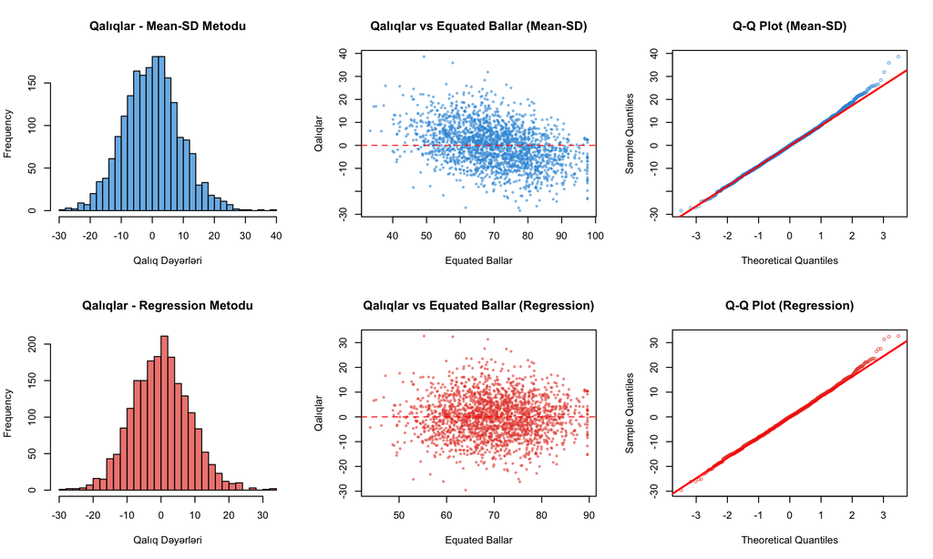

Qalıqların Təfərrüatlı Təhlili

```r
# Qalıqların təfərrüatlı vizualizasiyası
par(mfrow = c(2, 3))

# Mean-SD metodu qalıqları
hist(quality_ms$residuals, breaks = 30,
     col = adjustcolor(colors_custom[1], alpha.f = 0.7),
     main = "Qalıqlar - Mean-SD Metodu",
     xlab = "Qalıq Dəyərləri")

plot(exam_data$written_to_oral_ms, quality_ms$residuals,
     col = adjustcolor(colors_custom[1], alpha.f = 0.6), pch = 16, cex = 0.6,
     main = "Qalıqlar vs Equated Ballar (Mean-SD)",
     xlab = "Equated Ballar", ylab = "Qalıqlar")
abline(h = 0, col = "red", lty = 2)

# QQ plot - Mean-SD
qqnorm(quality_ms$residuals, main = "Q-Q Plot (Mean-SD)", cex = 0.6,
       col = adjustcolor(colors_custom[1], alpha.f = 0.6))
qqline(quality_ms$residuals, col = "red", lwd = 2)

# Regression metodu qalıqları
hist(quality_reg$residuals, breaks = 30,
     col = adjustcolor(colors_custom[2], alpha.f = 0.7),
     main = "Qalıqlar - Regression Metodu",
     xlab = "Qalıq Dəyərləri")

plot(exam_data$written_to_oral_reg, quality_reg$residuals,
     col = adjustcolor(colors_custom[2], alpha.f = 0.6), pch = 16, cex = 0.6,
     main = "Qalıqlar vs Equated Ballar (Regression)",
     xlab = "Equated Ballar", ylab = "Qalıqlar")
abline(h = 0, col = "red", lty = 2)

# QQ plot - Regression
qqnorm(quality_reg$residuals, main = "Q-Q Plot (Regression)", cex = 0.6,
       col = adjustcolor(colors_custom[2], alpha.f = 0.6))
qqline(quality_reg$residuals, col = "red", lwd = 2)
```

# 8 Praktiki Məsələlər və Həllər

## 8.1 Müxtəlif Korrelyasiya Hallarının Təhlili

```r
# Müxtəlif korrelyasiya hallarının simulyasiyası
simulate_correlation_scenario <- function(n, correlation, mean_x = 70, sd_x = 10,
                                        mean_y = 75, sd_y = 12, seed = NULL) {
  if (!is.null(seed)) set.seed(seed)

  # İki dəyişən arasında müəyyən korrelyasiya yaratmaq
  x <- rnorm(n, mean_x, sd_x)
  error_var <- (1 - correlation^2) * sd_y^2
  y <- mean_y + correlation * (sd_y/sd_x) * (x - mean_x) +
      rnorm(n, 0, sqrt(error_var))

  # Məhdudlaşdırma
  x <- pmax(0, pmin(100, x))
  y <- pmax(0, pmin(100, y))

  actual_correlation <- cor(x, y)

  return(list(x = x, y = y, target_cor = correlation, actual_cor = actual_correlation))
}

# Müxtəlif korrelyasiya ssenarilərini yaradın
scenarios <- list(
  high_cor = simulate_correlation_scenario(1000, 0.9, seed = 111),
  medium_cor = simulate_correlation_scenario(1000, 0.5, seed = 222),
  low_cor = simulate_correlation_scenario(1000, 0.2, seed = 333)
)

# Hər ssenari üçün equating aparın
scenario_results <- data.frame(
  Scenario = c("Yüksək Korrelyasiya", "Orta Korrelyasiya", "Aşağı Korrelyasiya"),
  Target_Correlation = c(0.9, 0.5, 0.2),
  Actual_Correlation = c(scenarios$high_cor$actual_cor,
                        scenarios$medium_cor$actual_cor,
                        scenarios$low_cor$actual_cor),
  MS_Slope = NA,
  MS_Intercept = NA,
  Reg_Slope = NA,
  Reg_Intercept = NA,
  Method_Difference = NA
)

for (i in 1:3) {
  scenario_name <- names(scenarios)[i]
  x_data <- scenarios[[scenario_name]]$x
  y_data <- scenarios[[scenario_name]]$y

  # Mean-SD metodu
  eq_ms <- linear_equating_mean_sd(x_data, y_data)
  # Regression metodu
  eq_reg <- linear_equating_regression(x_data, y_data)

  scenario_results$MS_Slope[i] <- eq_ms$slope
  scenario_results$MS_Intercept[i] <- eq_ms$intercept
  scenario_results$Reg_Slope[i] <- eq_reg$slope
  scenario_results$Reg_Intercept[i] <- eq_reg$intercept

  # Orta bala görə metodlar arasında fərq
  avg_score <- 70
  ms_transform <- eq_ms$intercept + eq_ms$slope * avg_score
  reg_transform <- eq_reg$intercept + eq_reg$slope * avg_score
  scenario_results$Method_Difference[i] <- abs(ms_transform - reg_transform)
}

scenario_results[, 3:8] <- round(scenario_results[, 3:8], 4)

cat("=== Müxtəlif Korrelyasiya Ssenarilərinin Nəticələri ===\n")
```

```
## === Müxtəlif Korrelyasiya Ssenarilərinin Nəticələri ===
```

```r
kable(scenario_results,
      caption = "Korrelyasiyanın Equating Nəticələrinə Təsiri",
      align = c("l", "c", "c", "c", "c", "c", "c", "c"))
```

Korrelyasiyanın Equating Nəticələrinə Təsiri

| Scenario | Target_Correlation | Actual_Correlation | MS_Slope | MS_Intercept | Reg_Slope | Reg_Intercept | Method_Difference |
| --- | --- | --- | --- | --- | --- | --- | --- |
| Yüksək Korrelyasiya | 0.9 | 0.9027 | 1.2025 | -9.5860 | 1.0855 | -1.3872 | 0.0126 |
| Orta Korrelyasiya | 0.5 | 0.5210 | 1.1816 | -7.9075 | 0.6157 | 31.6195 | 0.0904 |
| Aşağı Korrelyasiya | 0.2 | 0.2644 | 1.1932 | -8.5701 | 0.3155 | 53.0307 | 0.1601 |

```r
# Praktiki təfsir
cat("\n=== Praktiki Təfsir ===\n")
```

```
##
## === Praktiki Təfsir ===
```

```r
cat("• Yüksək korrelyasiya halında metodlar arasında fərq minimal\n")
```

```
## • Yüksək korrelyasiya halında metodlar arasında fərq minimal
```

```r
cat("• Aşağı korrelyasiya halında metodlar arasında fərq artır\n")
```

```
## • Aşağı korrelyasiya halında metodlar arasında fərq artır
```

```r
cat("• Regression metodu korrelyasiyanı nəzərə alır, Mean-SD metodu almır\n")
```

```
## • Regression metodu korrelyasiyanı nəzərə alır, Mean-SD metodu almır
```

## 8.2 Kiçik Nümunə Ölçüsünün Təsiri

```r
# Müxtəlif nümunə ölçülərinin təsirini tədqiq edin
sample_sizes <- c(50, 100, 200, 500, 1000)
n_simulations <- 100

small_sample_analysis <- function(n, n_sim = 100) {
  results <- matrix(NA, n_sim, 4)
  colnames(results) <- c("MS_Slope", "MS_Intercept", "Reg_Slope", "Reg_Intercept")

  for (i in 1:n_sim) {
    # Sabit populyasiya parametrləri
    scenario <- simulate_correlation_scenario(n, 0.7, seed = NULL)

    eq_ms <- linear_equating_mean_sd(scenario$x, scenario$y)
    eq_reg <- linear_equating_regression(scenario$x, scenario$y)

    results[i, ] <- c(eq_ms$slope, eq_ms$intercept, eq_reg$slope, eq_reg$intercept)
  }

  return(results)
}

# Hər nümunə ölçüsü üçün simulyasiya
cat("=== Kiçik Nümunə Ölçüsü Analizi ===\n")
```

```
## === Kiçik Nümunə Ölçüsü Analizi ===
```

```r
cat("Simulyasiyalar aparılır...\n")
```

```
## Simulyasiyalar aparılır...
```

```r
sample_size_results <- data.frame(
  Sample_Size = sample_sizes,
  MS_Slope_SD = NA,
  MS_Intercept_SD = NA,
  Reg_Slope_SD = NA,
  Reg_Intercept_SD = NA
)

for (i in 1:length(sample_sizes)) {
  n <- sample_sizes[i]
  sim_results <- small_sample_analysis(n, 50)  # Az simulyasiya sürət üçün

  sample_size_results$MS_Slope_SD[i] <- sd(sim_results[, "MS_Slope"])
  sample_size_results$MS_Intercept_SD[i] <- sd(sim_results[, "MS_Intercept"])
  sample_size_results$Reg_Slope_SD[i] <- sd(sim_results[, "Reg_Slope"])
  sample_size_results$Reg_Intercept_SD[i] <- sd(sim_results[, "Reg_Intercept"])
}

sample_size_results[, 2:5] <- round(sample_size_results[, 2:5], 4)

cat("=== Nümunə Ölçüsünün Parametr Sabitliyinə Təsiri ===\n")
```

```
## === Nümunə Ölçüsünün Parametr Sabitliyinə Təsiri ===
```

```r
kable(sample_size_results,
      caption = "Müxtəlif Nümunə Ölçüləri üçün Parametr Standart Sapmaları",
      align = "c")
```

Müxtəlif Nümunə Ölçüləri üçün Parametr Standart Sapmaları

| Sample_Size | MS_Slope_SD | MS_Intercept_SD | Reg_Slope_SD | Reg_Intercept_SD |
| --- | --- | --- | --- | --- |
| 50 | 0.0972 | 6.7293 | 0.1412 | 10.2523 |
| 100 | 0.0804 | 5.7971 | 0.0776 | 5.6035 |
| 200 | 0.0621 | 4.3461 | 0.0585 | 4.1442 |
| 500 | 0.0344 | 2.4254 | 0.0376 | 2.6263 |
| 1000 | 0.0261 | 1.8553 | 0.0252 | 1.8048 |

```r
# Minimum nümunə ölçüsü tövsiyəsi
cat("\n=== Tövsiyələr ===\n")
```

```
##
## === Tövsiyələr ===
```

```r
cat("• n < 100: Çox yüksək dəyişkənlik\n")
```

```
## • n < 100: Çox yüksək dəyişkənlik
```

```r
cat("• n = 200-500: Məqbul sabitlik\n")
```

```
## • n = 200-500: Məqbul sabitlik
```

```r
cat("• n > 500: Yaxşı sabitlik\n")
```

```
## • n > 500: Yaxşı sabitlik
```

```r
cat("• Operational equating üçün minimum n = 300 tövsiyə edilir\n")
```

```
## • Operational equating üçün minimum n = 300 tövsiyə edilir
```

# 9 Metodların Hərtərəfli Müqayisəsi

## 9.1 Bütün Metodların Performans Müqayisəsi

```r
# Hərtərəfli performans müqayisəsi funksiyası
comprehensive_evaluation <- function(original_x, original_y,
                                   equated_ms, equated_reg) {

  # RMSE hesablaması
  rmse_ms <- sqrt(mean((equated_ms - original_y)^2))
  rmse_reg <- sqrt(mean((equated_reg - original_y)^2))

  # MAE hesablaması
  mae_ms <- mean(abs(equated_ms - original_y))
  mae_reg <- mean(abs(equated_reg - original_y))

  # Bias hesablaması
  bias_ms <- mean(equated_ms - original_y)
  bias_reg <- mean(equated_reg - original_y)

  # Korelasiya
  cor_ms <- cor(equated_ms, original_y)
  cor_reg <- cor(equated_reg, original_y)

  # Ortalama və SD qorunması
  mean_preservation_ms <- abs(mean(equated_ms) - mean(original_y))
  mean_preservation_reg <- abs(mean(equated_reg) - mean(original_y))

  sd_preservation_ms <- abs(sd(equated_ms) - sd(original_y))
  sd_preservation_reg <- abs(sd(equated_reg) - sd(original_y))

  # Nəticələri birləşdir
  results <- data.frame(
    Method = c("Mean-SD", "Regression"),
    RMSE = c(rmse_ms, rmse_reg),
    MAE = c(mae_ms, mae_reg),
    Bias = c(bias_ms, bias_reg),
    Correlation = c(cor_ms, cor_reg),
    Mean_Preservation = c(mean_preservation_ms, mean_preservation_reg),
    SD_Preservation = c(sd_preservation_ms, sd_preservation_reg)
  )

  return(results)
}

# Universitaire məlumatlar üzərində hərtərəfli qiymətləndirmə
final_comparison <- comprehensive_evaluation(
  exam_data$written, exam_data$oral,
  exam_data$written_to_oral_ms, exam_data$written_to_oral_reg
)

final_comparison[, 2:7] <- round(final_comparison[, 2:7], 4)

cat("=== Son Performans Müqayisəsi ===\n")
```

```
## === Son Performans Müqayisəsi ===
```

```r
kable(final_comparison,
      caption = "Xətti Equating Metodlarının Hərtərəfli Müqayisəsi",
      align = c("l", rep("c", 6)))
```

Xətti Equating Metodlarının Hərtərəfli Müqayisəsi

| Method | RMSE | MAE | Bias | Correlation | Mean_Preservation | SD_Preservation |
| --- | --- | --- | --- | --- | --- | --- |
| Mean-SD | 9.0667 | 7.1780 | 0 | 0.7111 | 0 | 0.0000 |
| Regression | 8.3863 | 6.6291 | 0 | 0.7111 | 0 | 3.4469 |

```r
# Hansı metodun daha yaxşı olduğunu müəyyən et
better_method <- ifelse(final_comparison$RMSE[1] < final_comparison$RMSE[2],
                       "Mean-SD", "Regression")

cat("\n=== Ümumi Nəticə ===\n")
```

```
##
## === Ümumi Nəticə ===
```

```r
cat("RMSE əsasında daha yaxşı metod:", better_method, "\n")
```

```
## RMSE əsasında daha yaxşı metod: Regression
```

```r
# Metodlar arasında statistik fərqin yoxlanması
diff_rmse <- abs(final_comparison$RMSE[1] - final_comparison$RMSE[2])
relative_improvement <- (max(final_comparison$RMSE) - min(final_comparison$RMSE)) /
                       max(final_comparison$RMSE) * 100

cat("RMSE fərqi:", round(diff_rmse, 4), "\n")
```

```
## RMSE fərqi: 0.6804
```

```r
cat("Nisbi yaxşılaşma:", round(relative_improvement, 2), "%\n")
```

```
## Nisbi yaxşılaşma: 7.5 %
```

```r
# Praktiki əhəmiyyət
if (relative_improvement > 5) {
  cat("Praktiki cəhətdən əhəmiyyətli fərq var.\n")
} else {
  cat("Praktiki cəhətdən əhəmiyyətli fərq yoxdur.\n")
}
```

```
## Praktiki cəhətdən əhəmiyyətli fərq var.
```